# AIML CA1

## Regression

Name: Glenn Wu Adm. No: 2214395 Class: DAAA/FT/2A/01

- How is your prediction task defined? And what is the meaning of the output variable?
- Did you process the features in any way?
- How did you select which learning algorithms to use?
- Did you try to tune the hyperparameters of the learning algorithm, and in that case how?
- How do you evaluate the quality of your system?
- How well does your system compare to a dummy baseline?
- Can you say anything about the errors that the system makes?
- Is it possible to say something about which features the model considers important?

```python
import pandas as pd
import numpy as np
import matplotlib.pyplot as plt
import seaborn as sns
import sklearn
import xgboost
import warnings
import random
import math
```

```python
from sklearn.model_selection import cross_validate
from sklearn.pipeline import make_pipeline
from sklearn.dummy import DummyRegressor
from sklearn.linear_model import LinearRegression, Ridge, Lars, Lasso, LassoLars, BayesianRidge, ElasticNet, SGDRegressor
from sklearn.svm import SVR
from sklearn.kernel_ridge import KernelRidge
from sklearn.neighbors import KNeighborsRegressor
from sklearn.tree import DecisionTreeRegressor
from sklearn.ensemble import GradientBoostingRegressor, RandomForestRegressor, StackingRegressor

from sklearn.compose import ColumnTransformer
from sklearn.model_selection import train_test_split, GridSearchCV, RandomizedSearchCV, KFold, cross_validate
from sklearn.preprocessing import OrdinalEncoder, OneHotEncoder, StandardScaler, MinMaxScaler
```

```python
df = pd.read_csv("housing_dataset.csv")

# Display the first few rows of the dataset
(rows_len, cols_len) = df.shape
print(f"Number of Columns: {cols_len}")
print(f"Number of Rows: {rows_len}")
df.head()
```

```
Number of Columns: 8
Number of Rows: 545
```

|  | House ID | City | House Area (sqm) | No. of Bedrooms | No. of Toilets | Stories | Renovation Status | Price ($) |
| --- | --- | --- | --- | --- | --- | --- | --- | --- |
| 0 | 0 | Chicago | 742.0 | 4 | 2 | 3 | furnished | 1330000 |
| 1 | 1 | Denver | 896.0 | 4 | 4 | 4 | furnished | 1225000 |
| 2 | 2 | Chicago | 996.0 | 3 | 2 | 2 | semi-furnished | 1225000 |
| 3 | 3 | Seattle | 750.0 | 4 | 2 | 2 | furnished | 1221500 |
| 4 | 4 | New York | 742.0 | 4 | 1 | 2 | furnished | 1141000 |

# Exploratory Data Analysis

We will begin by conducting an exploratory data analysis of the data, to gain a better understanding of the characteristics of the dataset.

The dataset is about Housing Prices in 5 major cities in the US. There are 545 rows and 8 columns.  
**House ID**: Unique house identifier ranging from 0 to 544  
**City**: Which city the house is located  
**House Area**: Size of the house in square meters  
**No. of Bedrooms**: How many bedrooms in the house  
**No. of Toilets**: How many toilets in the house  
**Stories**: The number of stories in the house  
**Renovation Status**: How well the house is renovated  
**Price**: The price of the house in US dollars

## Data Exploration

```python
eda_df = df.copy()
```

- To prevent mutation of the original data during EDA, we will make a copy of it.
- House ID is a unique identifier and is independent from the values and thus should be dropped

### Descriptive Statistics

```python
# Summary statistics of the dataset
eda_df.describe()
```

|  | House ID | House Area (sqm) | No. of Bedrooms | No. of Toilets | Stories | Price ($) |
| --- | --- | --- | --- | --- | --- | --- |
| count | 545.00000 | 545.000000 | 545.000000 | 545.000000 | 545.000000 | 5.450000e+02 |
| mean | 272.00000 | 515.054128 | 2.965138 | 1.286239 | 1.805505 | 4.766729e+05 |
| std | 157.47222 | 217.014102 | 0.738064 | 0.502470 | 0.867492 | 1.870440e+05 |
| min | 0.00000 | 165.000000 | 1.000000 | 1.000000 | 1.000000 | 1.750000e+05 |
| 25% | 136.00000 | 360.000000 | 2.000000 | 1.000000 | 1.000000 | 3.430000e+05 |
| 50% | 272.00000 | 460.000000 | 3.000000 | 1.000000 | 2.000000 | 4.340000e+05 |
| 75% | 408.00000 | 636.000000 | 3.000000 | 2.000000 | 2.000000 | 5.740000e+05 |
| max | 544.00000 | 1620.000000 | 6.000000 | 4.000000 | 4.000000 | 1.330000e+06 |

```python
eda_df.isna().sum()
```

```
House ID             0
City                 0
House Area (sqm)     0
No. of Bedrooms      0
No. of Toilets       0
Stories              0
Renovation Status    0
Price ($)            0
dtype: int64
```

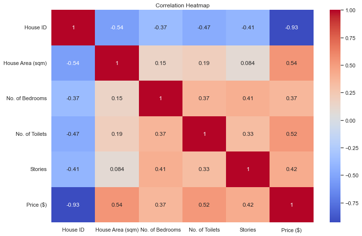

```python
sns.set()

# Correlation matrix
plt.figure(figsize=(12, 8))
sns.heatmap(eda_df.corr(), annot=True, cmap='coolwarm')
plt.title('Correlation Heatmap')
plt.show()
```

- The original dataset is sorted in descending order of Price, thus the high correlation between House ID and Price.

```python
categorical_cols = ["City", "No. of Bedrooms", "No. of Toilets", "Stories", "Renovation Status"]\

# Create another DataFrame with the same structure
df_target = pd.DataFrame(columns=eda_df.columns).drop(columns=categorical_cols)

# Select columns of type int or float from the source DataFrame
numeric_columns = eda_df.select_dtypes(include=['int', 'float']).columns

# Set the values in the target DataFrame
df_target[numeric_columns] = eda_df[numeric_columns]
```

### Data Distribution

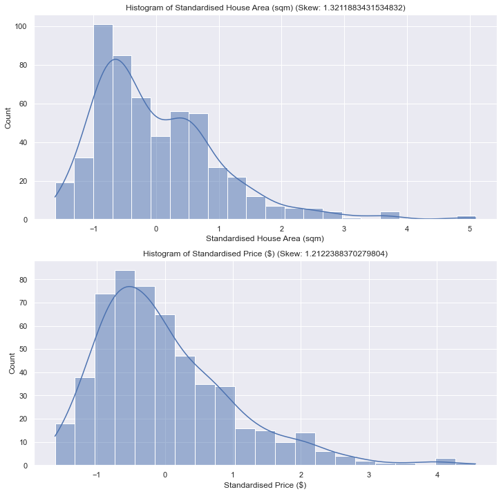

```python
from sklearn.preprocessing import StandardScaler

numerical_cols = ["House Area (sqm)", "Price ($)"]

for col in numerical_cols:
    eda_df[f"Standardised {col}"] = StandardScaler().fit_transform(np.array(eda_df[col]).reshape(-1, 1))

fig, axes = plt.subplots(nrows=len(numerical_cols), ncols=1, figsize=(12, 6*len(numerical_cols)))

for i, col in enumerate(numerical_cols):
    col = f"Standardised {col}"
    sns.histplot(data=eda_df, x=col, ax=axes[i], kde=True)
    axes[i].set_title(f"Histogram of {col} (Skew: {eda_df[col].skew()})")

plt.show()
```

- Both House Area and Price are skewed to the right, with high skews (>0.5)
- Models with using some form of Linear Regression do not assume the data is normal but they do assume that the residuals are normal which they usually are not when the data is skewed.
- I have found experimentally that using a Log transformation to unskew the data somewhat increases the score function and decreases the error function.

[figure not shown]

```python
# Scatter plot: House Area vs Price
plt.figure(figsize=(8, 6))
sns.scatterplot(data=eda_df, x="House Area (sqm)", y="Price ($)")
plt.title("House Area vs Price")
plt.show()
```

- There is correlation between House Area and Price

```python
from sklearn.preprocessing import StandardScaler

log_scaled_df = pd.DataFrame()
log_scaled_df["Log of House Area (sqm)"] = np.log1p(eda_df["House Area (sqm)"])
log_scaled_df["Log of Price ($)"] = np.log1p(eda_df["Price ($)"])

log_scaled_df = pd.DataFrame(StandardScaler().fit_transform(log_scaled_df), columns=log_scaled_df.columns)
```

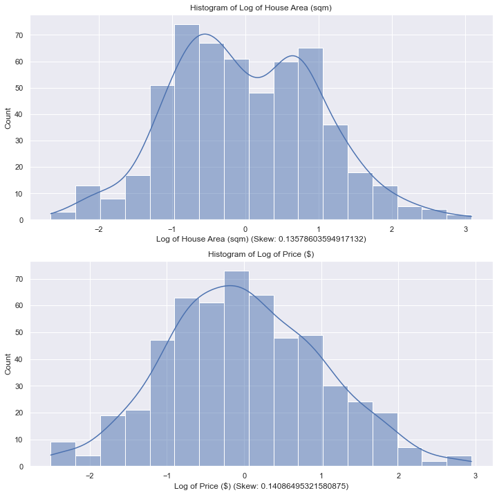

```python
numerical_cols = ["Log of House Area (sqm)", "Log of Price ($)"]

fig, axes = plt.subplots(nrows=len(numerical_cols), ncols=1, figsize=(12, 6*len(numerical_cols)))

for i, col in enumerate(numerical_cols):
    sns.histplot(data=log_scaled_df, x=numerical_cols[i], ax=axes[i], kde=True)
    axes[i].set_title(f"Histogram of {numerical_cols[i]}")
    axes[i].set_xlabel(f"{axes[i].get_xlabel()} (Skew: {log_scaled_df[numerical_cols[i]].skew()})")

plt.show()
```

- The skews have been rectified using a Log Transformation.

https://statisticaloddsandends.wordpress.com/2021/02/19/the-box-cox-and-yeo-johnson-transformations-for-continuous-variables/

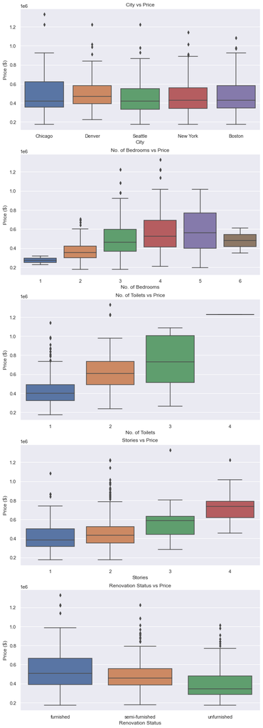

```python
categorical_cols = ["City", "No. of Bedrooms", "No. of Toilets", "Stories", "Renovation Status"]

fig, axes = plt.subplots(nrows=len(categorical_cols), ncols=1, figsize=(10, 6*len(categorical_cols)))

for i, col in enumerate(categorical_cols):
    sns.boxplot(data=df, x=categorical_cols[i], y="Price ($)", ax=axes[i])
    axes[i].set_title(f"{categorical_cols[i]} vs Price")

plt.show()
```

## Data Preprocessing & Feature Engineering

```python
df = df.drop("House ID", axis=1)
scaled_df = df.copy()

scaled_df["House Area (sqm)"] = np.log1p(scaled_df["House Area (sqm)"])
scaled_df["Price ($)"] = np.log1p(scaled_df["Price ($)"])

y = scaled_df["Price ($)"]
X = scaled_df.drop("Price ($)", axis=1)
```

```python
ordinal_encode = [["unfurnished", "semi-furnished", "furnished"],
                  ["1", "2", "3", "6", "4", "5"],
                  ["1", "2", "3", "4"],
                  ["1", "2", "3", "4"]]

X["No. of Bedrooms"] = X["No. of Bedrooms"].astype(str)
X["No. of Toilets"] = X["No. of Toilets"].astype(str)
X["Stories"] = X["Stories"].astype(str)

ct = ColumnTransformer(
    transformers=[
        ("standard_scaler", StandardScaler(), ["House Area (sqm)"]),
        ("one_hot_encoder", OneHotEncoder(), ["City"]),
        ("ordinal_toilet_no_and_stories_encoder",
         OrdinalEncoder(categories=ordinal_encode),
         ["Renovation Status", "No. of Bedrooms", "No. of Toilets", "Stories"])
    ],
    remainder="passthrough"
)

X_80, X_test, y_80, y_test = train_test_split(X, y, test_size=0.2, random_state=54)
# X_train, X_test, y_train, y_test = train_test_split(X, y, test_size=0.25, random_state=42)
```

## Model Selection

```python
models = [
    ("DummyRegressor", DummyRegressor()),
    ("LinearRegression", LinearRegression()),
    ("Ridge", Ridge()),
    ("Lasso", Lasso(random_state=23)),
    ("BayesianRidge", BayesianRidge()),
    ("ElasticNet", ElasticNet(random_state=23)),
    ("SGDRegressor", SGDRegressor(random_state=23)),
    ("SVR", SVR()),
    ("KernelRidge", KernelRidge()),
    ("KNeighborsRegressor", KNeighborsRegressor()),
    ("DecisionTreeRegressor", DecisionTreeRegressor(random_state=23)),
    ("GradientBoostingRegressor", GradientBoostingRegressor(random_state=23)),
    ("RandomForestRegressor", RandomForestRegressor(random_state=23)),
]
```

```python
from sklearn.model_selection import cross_validate
from sklearn.pipeline import make_pipeline

# pipeline = make_pipeline(prep, resampler, classifier)

def cv_scoring(pipeline, X, y, scoring={}, cv=KFold(n_splits=5, shuffle=True, random_state=42), n_jobs=-1):
#     print(pipeline, scoring, cv, n_jobs)
    cv_scores = cross_validate(pipeline, X, y, scoring=scoring, cv=cv, n_jobs=n_jobs)
    avg_scores = {}
#     print(cv_scores)
    for key, value in cv_scores.items():
        if "test_" in key or "train_" in key:
            avg_scores[key] = np.mean(value)
    return avg_scores
```

### Scoring Metrics

RMSE is more sensitive to outliers than MAE which is important in our context to not neglect predictions that are very wrong.

### KFold Cross Validation

- I will use cross-validation with different splits of data so that it's less likely for the model I select to be overfit.

```python
from sklearn.metrics import make_scorer, mean_squared_error, mean_absolute_error, r2_score
def expm1_rmse(y_true, y_pred):
    y_true = np.expm1(y_true)
    y_pred = np.expm1(y_pred)
    return mean_squared_error(y_true, y_pred, squared=False)
rmse = make_scorer(expm1_rmse, greater_is_better=False)

def expm1_mae(y_true, y_pred):
    y_true = np.expm1(y_true)
    y_pred = np.expm1(y_pred)
    return mean_absolute_error(y_true, y_pred)
mae = make_scorer(expm1_mae, greater_is_better=False)

def expm1_r2_score(y_true, y_pred):
    y_true = np.expm1(y_true)
    y_pred = np.expm1(y_pred)
    return r2_score(y_true, y_pred)
r2s = make_scorer(expm1_r2_score)
```